# Weight Lifting Exercise Predictive Model

Daniel Friedheim

7/2/2017

## Course Project, Practical Machine Learning

### Summary:

#### Predicting incorrect, as well as correct, weight lifting

We built a classification model trained on data from accelerometers on a weight and the belt, arm and forearm (*Figure 1*, below) of six human subjects to predict whether they executed 10 repetitions of a simple Unilateral Dumbbell Biceps Curl exercise correctly, or not. See the Weight Lifting Exercises Dataset collected by the [Human Activity Recognition project (HAR)](http://groupware.les.inf.puc-rio.br/har) at the Catholic University of Rio de Janeiro (Brazil).

Since we predicted those responses without any subject matter expertise to select plausible causal features, we built four alternative models that select features automatically. Then, we assessed their **Out of Sample Error** with cross-validation on a training subset and their Accuracy in predicting a separate validation subset. No model stacking was necessary.

Finally, we made predictions on a very small testing set with the most accurate model, cross-validated *Random Forest*. Its Accuracy was only slightly higher than a much faster *Support Vector Machines* model and a slightly faster *Generalized Boosted-regression Model*. Each of those three were much more accurate than a *Linear Discriminant Analysis* model.

*Fig. 1*, Location of Accelerometers:

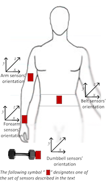

```r
library(plyr)
library(dplyr)
library(caret)
library(kernlab)
library(randomForest)
library(ggplot2)
library(ggthemes)
options(digits = 3, max.print = 200)
```

#### Getting the Dataset

We used a version of the original dataset already split into a very large `training` set (N=19622) and a very small `testing` set (N=20) for the *Practical Machine Learning* course. They contained 160 features.

```r
urlTrain <- "https://d396qusza40orc.cloudfront.net/predmachlearn/pml-training.csv"
urlTest <- "https://d396qusza40orc.cloudfront.net/predmachlearn/pml-testing.csv"
download.file(urlTrain, destfile = "./data/pml-training.csv", method = "curl")
download.file(urlTest, destfile = "./data/pml-testing.csv", method = "curl")
training = read.csv("./data/pml-training.csv", na.strings = c("", "NA"))
testing = read.csv("./data/pml-testing.csv", na.strings = c("", "NA"))
dim(training)
```

```
[1] 19622   160
```

```r
dim(testing)
```

```
[1]  20 160
```

### Data Preparation

#### 1. too many NAs in most features

Visual inspection of the dataset summary (not included here) immediately revealed one major problem: 19,216 of the 19,622 records contained only `NA` or `#DIV/0!` for 100 of the 160 features rendering them useless for prediction. Here are the counts of features with 0 or 19,216 `NAs`, the only combinations in the entire dataset:

```r
trainingIsNA <- is.na.data.frame(training)
table(apply(trainingIsNA, 2, sum))
```

```
    0 19216
   60   100
```

```r
trainingAnyNAs <- apply(training, 2, anyNA)
table(trainingAnyNAs)
```

```
trainingAnyNAs
FALSE  TRUE
   60   100
```

So, the first data cleaning step was simply to drop all 100 features containing mostly `NA` and `#DIV/0!`, leaving 60 features and 19,622 complete records.

```r
trainingNoNAs <- training[, trainingAnyNAs == FALSE]
dim(trainingNoNAs)
```

```
[1] 19622    60
```

A second feature selection step was to drop seven non-numeric features that had no predictive value leaving a slimmed-down `training` set with only 53 features.

```r
trainingCleanVars <- trainingNoNAs[, -c(1:7)]
dim(trainingCleanVars)
```

```
[1] 19622    53
```

While the reduction in features might sound a bit drastic, those remaining covered readings of all three dimensions (`x`, `y` and `z`) from all four accelerometers (`dumbell`, `belt`, `arm` and `forearm`), as well as the `classe` response, a non-numeric factor.

```r
names(trainingCleanVars)
```

```
 [1] "roll_belt"            "pitch_belt"           "yaw_belt"
 [4] "total_accel_belt"     "gyros_belt_x"         "gyros_belt_y"
 [7] "gyros_belt_z"         "accel_belt_x"         "accel_belt_y"
[10] "accel_belt_z"         "magnet_belt_x"        "magnet_belt_y"
[13] "magnet_belt_z"        "roll_arm"             "pitch_arm"
[16] "yaw_arm"              "total_accel_arm"      "gyros_arm_x"
[19] "gyros_arm_y"          "gyros_arm_z"          "accel_arm_x"
[22] "accel_arm_y"          "accel_arm_z"          "magnet_arm_x"
[25] "magnet_arm_y"         "magnet_arm_z"         "roll_dumbbell"
[28] "pitch_dumbbell"       "yaw_dumbbell"         "total_accel_dumbbell"
[31] "gyros_dumbbell_x"     "gyros_dumbbell_y"     "gyros_dumbbell_z"
[34] "accel_dumbbell_x"     "accel_dumbbell_y"     "accel_dumbbell_z"
[37] "magnet_dumbbell_x"    "magnet_dumbbell_y"    "magnet_dumbbell_z"
[40] "roll_forearm"         "pitch_forearm"        "yaw_forearm"
[43] "total_accel_forearm"  "gyros_forearm_x"      "gyros_forearm_y"
[46] "gyros_forearm_z"      "accel_forearm_x"      "accel_forearm_y"
[49] "accel_forearm_z"      "magnet_forearm_x"     "magnet_forearm_y"
[52] "magnet_forearm_z"     "classe"
```

We double-checked that the same number of incomplete features…

```r
testingNoNAs <- testing[, trainingAnyNAs == FALSE]
dim(testingNoNAs)
```

```
[1] 20 60
```

…and non-numeric features were dropped from the much smaller `testing` dataset, as well.

```r
testingCleanVars <- testingNoNAs[, -c(1:7)]
dim(testingCleanVars)
```

```
[1] 20 53
```

Finally, we confirmed that none of the retained features suffered from non-zero variance.

```r
NearZeroClean <- nzv(trainingCleanVars, saveMetrics = TRUE)
sum(NearZeroClean$nzv)
```

```
[1] 0
```

### Split off extra validation subset

#### (for assessing model Accuracy):

Taking advantage of the `training` set’s large size, we subsetted it into still large `train` (N=14718) and `valid` (N=4904) subsets for model building and assessment, respectively, as well as features-only (52) and response-only (1) alternatives for convenience.

```r
set.seed(34567)
inTrain <- createDataPartition(trainingCleanVars$classe, p = 0.75, list = FALSE)
trainCleanVars <- trainingCleanVars[inTrain, ]
validCleanVars <- trainingCleanVars[-inTrain, ]
trainFeatures <- as.matrix(trainCleanVars[, -53])
trainResponse <- as.factor(trainCleanVars[, 53])
validFeatures <- validCleanVars[, -53]
validResponse <- validCleanVars[, 53]
dim(trainFeatures)
```

```
[1] 14718    52
```

```r
str(trainResponse)
```

```
 Factor w/ 5 levels "A","B","C","D",..: 1 1 1 1 1 1 1 1 1 1 ...
```

```r
dim(validFeatures)
```

```
[1] 4904   52
```

```r
str(validResponse)
```

```
 Factor w/ 5 levels "A","B","C","D",..: 1 1 1 1 1 1 1 1 1 1 ...
```

We confirmed that the resulting distribution of `classe` responses was similar for the two subsets:

```r
table(trainResponse)
```

```
trainResponse
   A    B    C    D    E
4185 2848 2567 2412 2706
```

```r
table(validResponse)
```

```
validResponse
   A    B    C    D    E
1395  949  855  804  901
```

### Cross Validation & Normalization

#### Cross Validation to measure Out of Sample Error

We set up **10-fold Cross Validation**—without repetition in order to conserve runtime) for the *Linear Discriminant Analysis* model and *Generalized Boosted-regression Model* executed in `caret`, leaving that to be set up directly in non-`caret` calls that built the *Support Vector Machines* and *Random Forest* models. (The choice of whether to build each type of model in `caret`, or not, was based on runtime.)

```r
ctrl <- trainControl(method = "cv", number = 10)
```

#### Scale and Center all features

Since the 52 features were all numeric or integer, we decided to scale and center them in each of the separate model algorithm calls below. While not strictly necessary for the *Generalized Boosted-regression Model* and *Random Forest* tree-generating models, this normalization was required for *Support Vector Machines* and would help for *Linear Discriminant Analysis*, too.

### Four alternative models with Cross Validation

#### 1. Linear Discriminant Analysis (LDA)

```r
set.seed(34567)
fitLda <- train(classe ~ ., data = trainCleanVars, method = "lda", preProc = c("center",
    "scale"), trControl = ctrl)
fitLda
```

```
Linear Discriminant Analysis

14718 samples
   52 predictor
    5 classes: 'A', 'B', 'C', 'D', 'E'

Pre-processing: centered (52), scaled (52)
Resampling: Cross-Validated (10 fold)
Summary of sample sizes: 13246, 13245, 13245, 13247, 13248, 13248, ...
Resampling results:

  Accuracy  Kappa
  0.701     0.622
```

The *LDA* model got fully 1,421 predictions wrong. So, its Confusion Matrix exhibited lots of error, both Type I false positives and Type II false negatives.

```r
predictLda <- predict(fitLda, validFeatures)
confusionMatrix(predictLda, validResponse)$table
```

```
          Reference
Prediction    A    B    C    D    E
         A 1140  128   69   56   40
         B   35  623   98   25  155
         C  115  123  576   94   81
         D  101   33   98  606   87
         E    4   42   14   23  538
```

```r
table(predictLda == validResponse)
```

```
FALSE  TRUE
 1421  3483
```

```r
confusionMatrix(predictLda, validResponse)$overall[1]
```

```
Accuracy
    0.71
```

#### 2. Generalized Boosted-regression Modeling (GBM) trees

**Out of Sample Error** for the *GBM* model built with `caret` was dramatically lower at 1 - `0.961`, or 3.9%, for the automatically-chosen tuning parameters of `n.trees` = `150` and `interactiondepth` = `3`. *GBM* got only 189 predictions wrong with slightly more Type I false positives than Type II false negatives. Runtime, though, was much longer, approx. 16:00 minutes.

```r
set.seed(34567)
fitGbm <- train(classe ~ ., data = trainCleanVars, method = "gbm", preProc = c("scale",
    "center"), trControl = ctrl, verbose = FALSE)
fitGbm
```

```
Stochastic Gradient Boosting

14718 samples
   52 predictor
    5 classes: 'A', 'B', 'C', 'D', 'E'

Pre-processing: scaled (52), centered (52)
Resampling: Cross-Validated (10 fold)
Summary of sample sizes: 13246, 13245, 13245, 13247, 13248, 13248, ...
Resampling results across tuning parameters:

  interaction.depth  n.trees  Accuracy  Kappa
  1                   50      0.754     0.688
  1                  100      0.825     0.778
  1                  150      0.857     0.819
  2                   50      0.855     0.817
  2                  100      0.908     0.884
  2                  150      0.933     0.915
  3                   50      0.899     0.873
  3                  100      0.945     0.930
  3                  150      0.964     0.954

Tuning parameter 'shrinkage' was held constant at a value of 0.1

Tuning parameter 'n.minobsinnode' was held constant at a value of 10
Accuracy was used to select the optimal model using  the largest value.
The final values used for the model were n.trees = 150,
 interaction.depth = 3, shrinkage = 0.1 and n.minobsinnode = 10.
```

```r
predictGbm <- predict(fitGbm, validCleanVars)
confusionMatrix(predictGbm, validCleanVars$classe)$table
```

```
          Reference
Prediction    A    B    C    D    E
         A 1361   27    0    0    1
         B   24  898   27    3    4
         C    7   23  818   26    7
         D    3    0   10  765   16
         E    0    1    0   10  873
```

```r
table(predictGbm == validCleanVars$classe)
```

```
FALSE  TRUE
  189  4715
```

```r
confusionMatrix(predictGbm, validCleanVars$classe)$overall[1]
```

```
Accuracy
   0.961
```

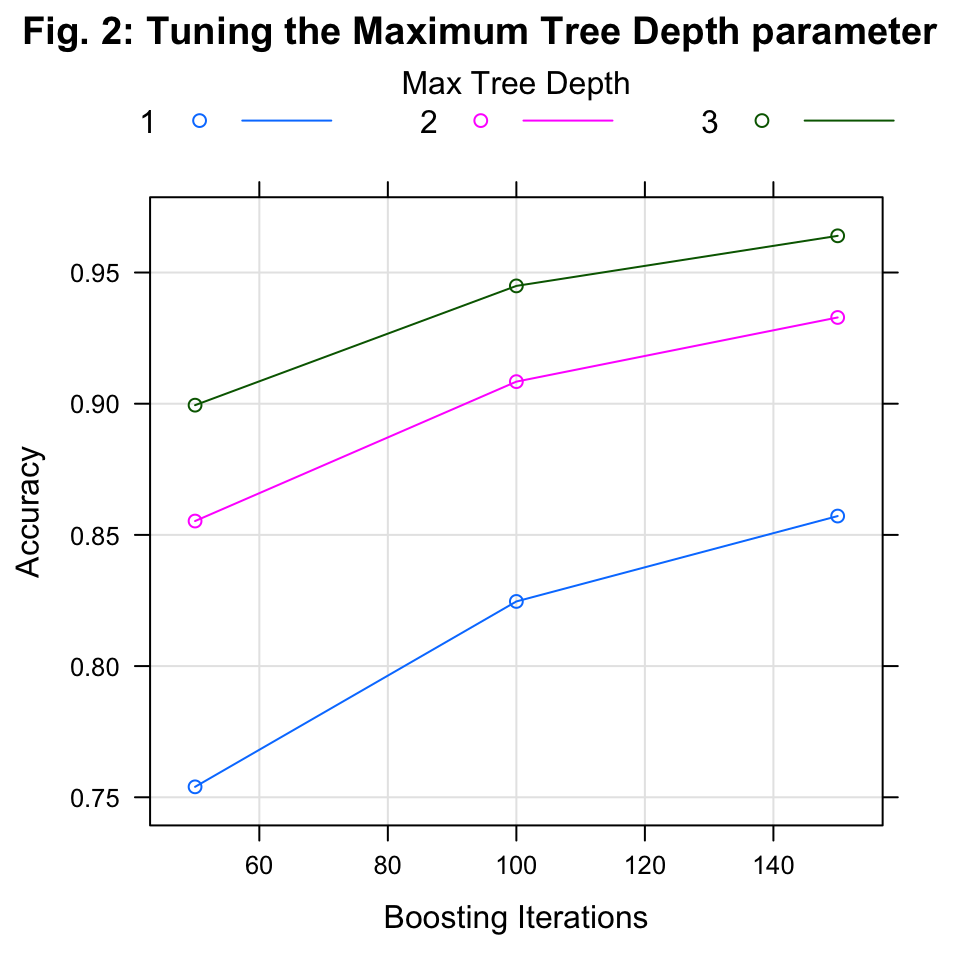

```r
plot(fitGbm, main = "Fig. 2: Tuning the Maximum Tree Depth parameter", ylab = "Accuracy",
    xlab = "Boosting Iterations")
```

#### 3. Support Vector Machines (SVM)

The *SVM* model, built with `ksvm` using the Radial Basis Function kernel in the `kernlab` package, scaled and centered all features by default, but **10-fold Cross Validation** had to be chosen manually by setting the `cross` option to 10.

**Out of Sample Error**, reported below as `Cross validation error`, was also impressively low at 1.8%, not much higher than the `Training error` of 1.2%. *SVM* got only 67 predictions wrong, mostly Type I false positives. Runtime was fast, too, approx. 2:00 minutes.

```r
set.seed(34567)
fitSVMrbf <- ksvm(classe ~ ., data = trainCleanVars, kernel = "rbfdot", scaled = TRUE,
    C = 16, cross = 10)
fitSVMrbf
```

```
Support Vector Machine object of class "ksvm"

SV type: C-svc  (classification)
 parameter : cost C = 16

Gaussian Radial Basis kernel function.
 Hyperparameter : sigma =  0.0137325880957421

Number of Support Vectors : 3838

Objective Function Value : -5166 -1622 -1440 -662 -3845 -1026 -1526 -6935 -2314 -1966
Training error : 0.01223
Cross validation error : 0.0179
```

```r
predictSVMrbf <- predict(fitSVMrbf, validCleanVars)
confusionMatrix(predictSVMrbf, validCleanVars$classe)$table
```

```
          Reference
Prediction    A    B    C    D    E
         A 1391   12    0    0    0
         B    4  934    1    0    0
         C    0    0  852   35    1
         D    0    1    2  769    9
         E    0    2    0    0  891
```

```r
table(predictSVMrbf == validCleanVars$classe)
```

```
FALSE  TRUE
   67  4837
```

```r
confusionMatrix(predictSVMrbf, validCleanVars$classe)$overall[1]
```

```
Accuracy
   0.986
```

#### 4. Random Forest (RF) bagged trees

##### Two Error rates: Out of Bag & Cross Validation

The **Out of Sample Error** of 0.9% for the *RF* model built with `randomForest` was the lowest of all. We tuned the `mtry` parameter to 13, as explained below, and therefore read the corresponding **Out of Sample Error** on the table line for 13 “variables” (i.e., randomly selected for consideration at each split). *RF* got only 17 (out of 4,904) predictions for the `valid` subset wrong, very few of either Type I or II.

```r
set.seed(34567)
fitRandomFcv500 <- rfcv(trainFeatures, trainResponse, cv.fold = 10)
str(fitRandomFcv500)
```

```
List of 3
 $ n.var    : num [1:6] 52 26 13 6 3 1
 $ error.cv : Named num [1:6] 0.0055 0.00666 0.00931 0.04253 0.10871 ...
  ..- attr(*, "names")= chr [1:6] "52" "26" "13" "6" ...
 $ predicted:List of 6
  ..$ 52: Factor w/ 5 levels "A","B","C","D",..: 1 1 1 1 1 1 1 1 1 1 ...
  ..$ 26: Factor w/ 5 levels "A","B","C","D",..: 1 1 1 1 1 1 1 1 1 1 ...
  ..$ 13: Factor w/ 5 levels "A","B","C","D",..: 1 1 1 1 1 1 1 1 1 1 ...
  ..$ 6 : Factor w/ 5 levels "A","B","C","D",..: 1 1 1 1 1 1 1 1 1 1 ...
  ..$ 3 : Factor w/ 5 levels "A","B","C","D",..: 1 1 1 1 1 1 1 1 1 1 ...
  ..$ 1 : Factor w/ 5 levels "A","B","C","D",..: 1 1 1 3 2 1 1 1 2 2 ...
```

```r
names(fitRandomFcv500)
```

```
[1] "n.var"     "error.cv"  "predicted"
```

```r
error <- as.numeric(fitRandomFcv500$error.cv)
variables <- as.numeric(fitRandomFcv500$n.var)
errorRates500 <- data.frame(cbind(variables, error))
errorRates500
```

```
  variables   error
1        52 0.00550
2        26 0.00666
3        13 0.00931
4         6 0.04253
5         3 0.10871
6         1 0.58846
```

*Figure 3* shows that **Out of Sample Error** does not drop much more beyond `n.var` = `13` variables at each tree split.

[figure not shown]

```r
ggplot(errorRates500) + aes(variables, error) + geom_point(color = "blue2") +
    theme_few() + geom_step(color = "blue2", alpha = 0.5) + scale_x_continuous(breaks = c(1,
    3, 6, 13, 26, 52)) + labs(y = "Out of Sample Error", x = "Variables at each split",
    title = "Fig. 3: Tuning Random Forest's mtry parameter:", subtitle = "OOB Error drops quickly until mtry reaches 13")
```

Based on that preliminary **Cross Validation** step, we decided to manually tune the *RF* model’s `mtry` parameter to `13`. Without needing to execute **Cross Validation** again, it then ran very quickly, approx. 1:00 minute.

```r
set.seed(34567)
fitRandomF <- randomForest(classe ~ ., trainCleanVars, mtry = 13)
fitRandomF
```

```
Call:
 randomForest(formula = classe ~ ., data = trainCleanVars, mtry = 13)
               Type of random forest: classification
                     Number of trees: 500
No. of variables tried at each split: 13

        OOB estimate of  error rate: 0.5%
Confusion matrix:
     A    B    C    D    E class.error
A 4180    2    1    1    1     0.00119
B   13 2830    5    0    0     0.00632
C    0   12 2551    4    0     0.00623
D    0    1   20 2388    3     0.00995
E    0    0    3    8 2695     0.00407
```

Although `randomForest` defaulted to growing 500 trees, *Figure 4* suggests that no more than 100 would be necessary to keep Out of Bag Error low, which might make deployment of an even faster model possible (but that’s beyond the scope of this report).

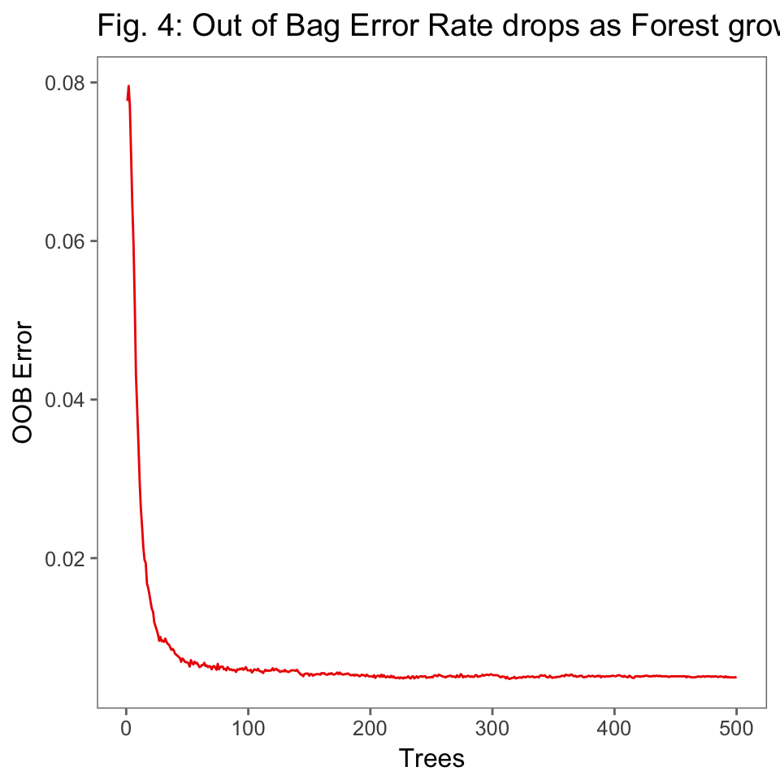

```r
OOBerrors <- data.frame(fitRandomF$err.rate)
ggplot(OOBerrors) + aes(row(OOBerrors)[, 1], OOBerrors[, 1]) + geom_line(color = "red2") +
    theme_few() + labs(title = "Fig. 4: Out of Bag Error Rate drops as Forest grows",
    y = "OOB Error", x = "Trees")
```

```r
predictRf <- predict(fitRandomF, validFeatures)
confusionMatrix(predictRf, validResponse)$table
```

```
          Reference
Prediction    A    B    C    D    E
         A 1392    2    0    0    0
         B    3  945    3    0    0
         C    0    2  851    5    1
         D    0    0    1  799    0
         E    0    0    0    0  900
```

```r
table(predictRf == validResponse)
```

```
FALSE  TRUE
   17  4887
```

```r
confusionMatrix(predictRf, validResponse)$overall[1]
```

```
Accuracy
   0.997
```

### Final Predictions

```r
predictFinalLda <- predict(fitLda, testingCleanVars)
predictFinalGbm <- predict(fitGbm, testingCleanVars)
predictFinalSVM <- predict(fitSVMrbf, testingCleanVars)
predictFinalRF <- predict(fitRandomF, testingCleanVars)
```

Since the `classe` response feature was withheld from our small `testing` set, we settled for an hint indicator of potential success, instead—the encouraging fact that the top three models agreed completely. Only *LDA* disagreed, making 7 different predictions, presumably false, which was enough to eliminate it from further consideration.

```r
PredictionAgreement <- c(sum(predictFinalLda == predictFinalGbm), sum(predictFinalGbm ==
    predictFinalSVM), sum(predictFinalSVM == predictFinalRF))
ModelPairs <- c("LDA vs GBM", "GBM vs SVM", "SVM vs RF")
data.frame(cbind(ModelPairs, PredictionAgreement))
```

```
  ModelPairs PredictionAgreement
1 LDA vs GBM                  13
2 GBM vs SVM                  20
3  SVM vs RF                  20
```

#### Ranking models by Accuracy

Although the top three models were nearly indistinguishable, the table below ranks them—by **Out of Sample** `modelAccuracy` on the large `valid` subset, not just **cross validation** on the `train` subset—in this order: *RF* > *SVM* > *GBM* >> *LDA*.

```r
modelAccuracy <- c(RF = confusionMatrix(predictRf, validResponse)$overall[1],
    SVM = confusionMatrix(predictSVMrbf, validCleanVars$classe)$overall[1],
    GBM = confusionMatrix(predictGbm, validCleanVars$classe)$overall[1], LDA = confusionMatrix(predictLda,
        validResponse)$overall[1])
data.frame(modelAccuracy, row.names = c("RF", "SVM", "GBM", "LDA"))
```

```
    modelAccuracy
RF          0.997
SVM         0.986
GBM         0.961
LDA         0.710
```

### Conclusion:

Only *LDA* appeared to have failed to predict all 20 testing values. Of the remaining three models, *SVM* had the fastest runtime, but *RF* was most accurate by a very slim margin with *GBM* the also-ran on both dimensions. We opted for highest Accuracy over shortest runtime, choosing to make the final predictions with the *Random Forest* model despite its manual tuning, separate **Cross Validation**, and relative slowness. The final response values (from A through E) predicted by the doubly **Cross Validated** *RF* model were:

```r
as.matrix(predictFinalRF)
```

```
   [,1]
1  "B"
2  "A"
3  "B"
4  "A"
5  "A"
6  "E"
7  "D"
8  "B"
9  "A"
10 "A"
11 "B"
12 "C"
13 "B"
14 "A"
15 "E"
16 "E"
17 "A"
18 "B"
19 "B"
20 "B"
```

NOTE: wordcount < 1,500